# 1. Оценка Хилла (`Hill estimator`)

Пусть $\large X_1, \ldots, X_n$ - независимые одинаково распределённые случайные величины. Классическая теория экстремумов - асимптотическая теория распределения максимумов:

$$\large M_n = \max\left(X_1, \ldots, X_n\right)$$

Функция распределения максимумов $F_{M_n}(x)$:

$$\large F_{M_n}(x) = \left(F_{X_i}(x)\right)^n$$

В основе теории экстремальных значений главным результатом является теорема `Фишера-Типпета-Гнеденко`: если удаётся подобрать некоторые числовые последовательности $a_n > 0, b_n$, что $\left(F_{X_i}\left(\frac{x - b_n}{a_n}\right)\right)^n$ невырожденно при $n \to \infty$, то для независимых одинаково распределённых величин выполняется соотношение:

$$\left(F_{X_i}\left(\frac{x - b_n}{a_n}\right)\right)^n \to H_{\beta}(x)$$

где $H_{\beta}(x)$ - обобщённое распределение экстремальных значений (`Generalized Extreme Value Distribution (GEV)`), где $H_{\beta}(x)$ принадлежит одному из $3$-х экстремальных типов (существуют такие константы $a>0$ и $b$, что функция распределения $H(ax+b)$ в точности равна одной из указанных ниже функций распределения:

$$\large H_{\beta}(x) = \begin{cases} e^{-(1 + \beta x)^{-\frac{1}{\beta}}}, \beta \neq 0 \\ e^{e^{-x}}, \beta=0 \end{cases}$$

- $\beta > 0$ - распределение Фреше
- $\beta < 0$ - распределение Вейбулла
- $\beta = 0$ - распределение Гумбеля

Параметр $\beta$ называется `индексом экстремального значения` (extreme value index).

## 1.1 Описание

Задача оценки `индекса экстремального значения` является важной задачей. Одной из наиболее известных оценок индекса экстремального $\beta$ значения является оценка Хилла. Пусть последовательность независимых одинаково распределённых случайных величин имеет функцию распределения $F$, которая принадлежит области максимального притяэения `Фреше`. Рассмотрим вариационный ряд $X_{(1)} \leqslant \ldots \leqslant X_{(n)}$ выборки $X_i, i = 1, \ldots, n$. Выберем некоторое значение $k$ и возьмём следующую статистику в качестве оценки параметра $\beta$:

$$\large \hat{\beta} = H_{k, n} = \frac{1}{k}\sum\limits_{i=1}^k \left(\ln X_{(i)} - \ln X_{(k+1)}\right)$$

где $k$ - `tail treshold`. Оценка Хилла - это среднее значение $k$ наиболее экстремальных (хвостовых) наблюдений. Есть опасения насчет свойств метода Хилла на малых выборках и выбора порога $k$.

Выбор $k$ - сложная задача, описанная на копромиссе `bias` и `variance` - дисперсия и смещение. Если мы будем увеличивать значение порога $k$, то будем получать больше данных и перейдем к центру распределения, что увеличивает точность нашей оценки, но снижает дисперсию, но увеличивает оценку хвоста, придавая больший вес наблюдениям ближе к центру нашего распределения. Уменьшая $k$ - уменьшаем смещение, но имеем меньше данных и более высокую `variance`.

## 1.2 Свойства

1. Оценка методом Хилла является состоятельной: при $n \to \infty$, $k = k(n) \to \infty$ и $\frac{k}{n} \to 0$ оценка хилла $ H_{k, n}$ сходится по вероятности к индексу экстремальных значений.
2. Оценка методом Хилла вяляется асимптотически нормальной при $k, n \to \infty$:

$$\large \sqrt{k} \cdot (H_{k, n} - \beta) \overset{d}{\to} N \left(\frac{\lambda^2}{1 - \rho}, \beta\right)$$

где $N(0,1)$ - стандартная нормальная случайная веичина, $\lambda$ - параметр, что $\large \lim\limits_{n \to \infty} \sqrt{k} \cdot {A\left(\frac{n}{k}\right)} = \lambda$, а $A(t)$ - знакопостоянная, причём $\large \lim\limits_{t \to \infty} A(t) = 0$.

Некоторые говорят, что с другими [параметрами:](http://sfb649.wiwi.hu-berlin.de/fedc_homepage/xplore/tutorials/sfehtmlnode91.html)

```python
a = []
for i in range(100):
    num_sample = 10000
    gamma = 0.3
    k = 2
    samples = FrechetDistribution(num_sample, gamma)
    a.append(Hill_estimator(samples, k))
```

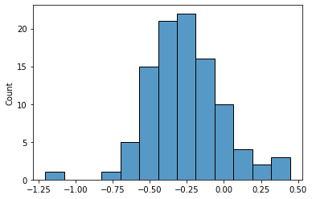

```python
sns.histplot(np.sqrt(k) * (np.array(a) - 0.2))
plt.show()
```

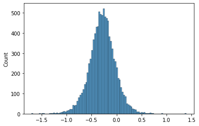

```python
a = []
for i in range(10000):
    num_sample = 10000
    gamma = 0.3
    k = 2
    samples = FrechetDistribution(num_sample, gamma)
    a.append(Hill_estimator(samples, k))
sns.histplot(np.sqrt(k) * (np.array(a) - 0.2))
plt.show()
```

## 1.3 Примеры

## 1.3.1 `Hill Plot`

Будем увеличивать параметр $k$, пока приблизительно не будет стабилизируется оценка параметра $\beta$.

```python
def FrechetDistribution(n, gamma):
    """
    Создание выборки из распределения Фреше с параметрами:
    n -- размер выборки
    gamma -- параметр распределения
    """
    samples = np.empty((n, ), dtype = np.float32)
    unifrom = np.random.uniform(0., 1.0, size = samples.shape)
    samples = (1./gamma)*((-1.*np.log(unifrom))**(-1.*gamma))
    return samples
```

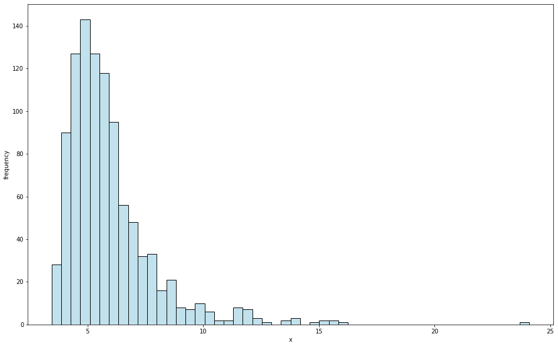

```python
num_sample = 1000 # количество сэмплов выборки
gamma = 0.2 # параметр распределения Фреше
FrechetSamples = FrechetDistribution(num_sample, gamma) # геренация выборки
PlotDistribution(FrechetSamples, bins=50) # построение выборки
```

```python
@njit([float64(float64[:], int64)])
def Hill_estimator(var_samples, k):
    """
    Вычисление оценки Хилла
    """
    estimator = 0.
    for i in range(k):
        estimator += np.log(var_samples[-(i + 1)]) - np.log(var_samples[-k])
    estimator /= k+1
    return estimator

def plotHillEstimator(samples):
    """
    Построение оценки Хилла
    """
    n = len(samples)
    var_samples = variation_series(samples)
    k_array = np.arange(n - 1)
    hill_estim = np.empty(k_array.shape, dtype=np.float32)
    for k, k_iter in enumerate(k_array):
        hill_estim[k] = Hill_estimator(var_samples, k_iter)

    fig, ax = plt.subplots(1, 1, figsize=(16, 10))
    ax.scatter(k_array, hill_estim, color='darkblue', s=15, alpha=0.7)
    ax.set_xlabel('k')
    ax.set_ylabel('Hill estimator')
    ax.set_title('dependence Hill estimator for different k')
    ax.grid(True)
    plt.show()
    return None
```

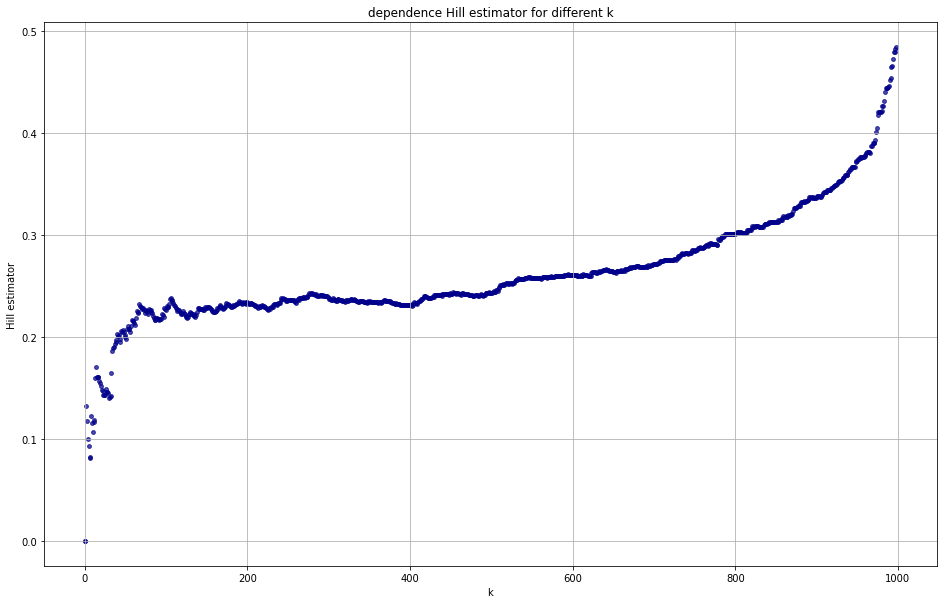

```python
plotHillEstimator(FrechetSamples)
```

## 1.3.2 `QQPlot`

Параметр находится с помощью следующей последовательности действий:

- параметр находится для каждой квантили и строятся `квантильно-квантильные графики` (QQPLOT)
- строится касательная к полученному квантильно-квантильному графику методом наименьших квадратов
- определяется тангенс угла в пересечении графика касательной с осью абсцисс. величина тангенса угла составляет искомый индекс $\beta$

```python
from scipy.stats import probplot
```

```
(1.729916394722549, 5.922160604636116, 0.886727978113613)
```

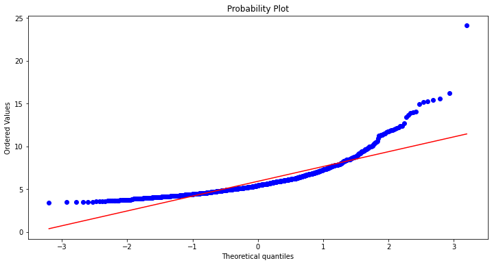

```python
fig, ax = plt.subplots(1, 1, figsize = (12, 6))
res = probplot(FrechetSamples,
               dist="norm",
               plot=ax)
print(res[1])
plt.show()
```

```python
samples = FrechetSamples
n = len(samples)
var_samples = variation_series(samples)
k_array = np.arange(n - 1)
hill_estim = np.empty(k_array.shape, dtype=np.float32)
for k, k_iter in enumerate(k_array):
    hill_estim[k] = Hill_estimator(var_samples, k_iter)
```

```
(0.05265999288622994, 0.26294422149658203, 0.9417543903965528)
```

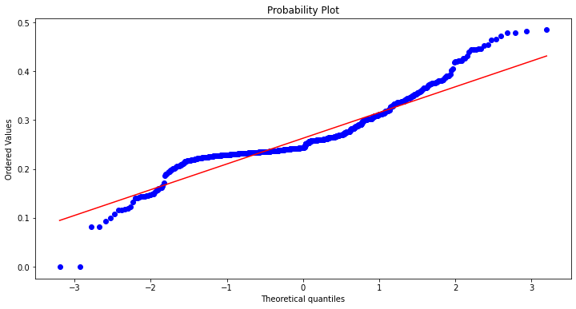

```python
fig, ax = plt.subplots(1, 1, figsize = (12, 6))
res2 = probplot(hill_estim,
               dist="norm",
               plot=ax)
print(res2[1])
plt.show()
```

## 1.4 Источники

- [QQplot метод](http://vestnik.osu.ru/2014_1/14.pdf)
- [Оригинальная статья Хилла](https://projecteuclid.org/download/pdf_1/euclid.aos/1176343247)
- Dowd, K. Measuring Market Risk, Wiley, 2007.
- [Доказательства состоятельности и асимтотической нормальности](http://mech.math.msu.su/~snark/files/diss/0003diss.pdf)
- [Просто хорошо написано](https://www.intechopen.com/books/statistical-methodologies/asymptotic-normality-of-hill-s-estimator-under-weak-dependence)
- [Тоже неплохо](http://sfb649.wiwi.hu-berlin.de/fedc_homepage/xplore/tutorials/sfehtmlnode91.html)
- [Simple Modification Hill](http://www.utstat.utoronto.ca/keith/papers/robusthill.pdf)